# semana-2

Diego Ramos & Patricio Bustos

2025-08-28

```r
datos <- read.csv2("EP02 Datos.csv")
```

## Pregunta 1:

El Comité Olímpico cree que el mejor tiempo medio de los atletas de la zona Sur después de ingresar al programa de entrenamiento es superior a 12,4 segundos. ¿Soportan los datos esta afirmación?

```r
# Primero obtenemos los datos de la zona Sur
zonaSur <- datos[datos$Zona == "Sur",]

x <- summary(zonaSur)
x
```

```
##        Id            Zona               Previo        Posterior
##  Min.   : 5.00   Length:28          Min.   :11.96   Min.   :10.69
##  1st Qu.:17.75   Class :character   1st Qu.:13.23   1st Qu.:11.82
##  Median :34.00   Mode  :character   Median :14.03   Median :12.42
##  Mean   :37.71                      Mean   :14.11   Mean   :12.55
##  3rd Qu.:58.25                      3rd Qu.:14.84   3rd Qu.:13.09
##  Max.   :81.00                      Max.   :17.30   Max.   :15.99
```

Por el enunciado sabemos que los datos son independientes. Y por la funcion summary se puede apreciar que los datos son < 30, 28 para ser exactos.

Ahora se analiza la normalidad de los datos:

```r
prueba <- shapiro.test(zonaSur$Posterior)
prueba
```

```
##
##  Shapiro-Wilk normality test
##
## data:  zonaSur$Posterior
## W = 0.95201, p-value = 0.2225
```

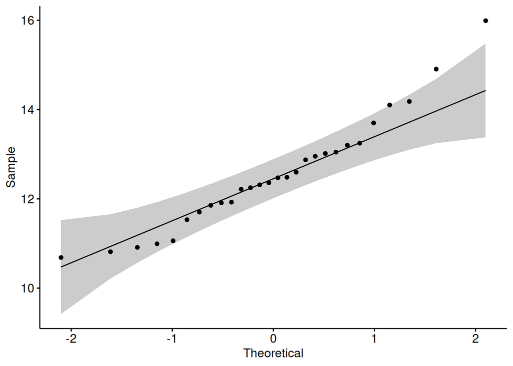

```r
ggqqplot(zonaSur, x="Posterior")
```

Dado que p = 0.2225 se puede aceptar que los datos son normales

Dada estas condiciones se puede aplica una prueba t con un 95% de confianza Donde:

- **$H_O$: media posterior = 12,4**
- **$H_A$: media posterior > 12,4**

```r
## definimos el nivel de confianza
alpha <- 0.05

t.test(zonaSur$Posterior, mu = 12.4, conf.level = 1 - alpha, alternative = "greater")
```

```
##
##  One Sample t-test
##
## data:  zonaSur$Posterior
## t = 0.62078, df = 27, p-value = 0.27
## alternative hypothesis: true mean is greater than 12.4
## 95 percent confidence interval:
##  12.14311      Inf
## sample estimates:
## mean of x
##  12.54732
```

## Pregunta 2

¿Sugieren los datos que la mejor marca de los atletas de la zona Centro-Norte se reduce en promedio 3,5 segundos tras el entrenamiento?

```r
#obtenemos los datos de la zona centro norte
zonaCentroNorte <- datos[datos$Zona == "Centro-Norte",]

y <- summary(zonaCentroNorte)
y
```

```
##        Id            Zona               Previo        Posterior
##  Min.   : 3.00   Length:26          Min.   :14.55   Min.   :11.49
##  1st Qu.:21.75   Class :character   1st Qu.:15.84   1st Qu.:12.95
##  Median :37.00   Mode  :character   Median :16.42   Median :13.45
##  Mean   :40.92                      Mean   :16.45   Mean   :13.37
##  3rd Qu.:62.00                      3rd Qu.:17.15   3rd Qu.:14.05
##  Max.   :79.00                      Max.   :18.03   Max.   :15.16
```

Por el enunciado sabemos que los datos son independientes. Y por la funcion summary podemos ver que los datos son menores a 30, 26 para ser especificos, en cada una de las muestras

Ahora verificaremos si los datos siguen una distribución normal, esto mediante una prueba de normalidad (shapiro.test)

```r
#dado que nos espesifican la mejor marca DESPUES DEL ENTRENAMIENTO entonces ocuparemos la columna POSTERIOR
shapiro.test(zonaCentroNorte$Posterior)
```

```
##
##  Shapiro-Wilk normality test
##
## data:  zonaCentroNorte$Posterior
## W = 0.94734, p-value = 0.2008
```

```r
shapiro.test(zonaCentroNorte$Previo)
```

```
##
##  Shapiro-Wilk normality test
##
## data:  zonaCentroNorte$Previo
## W = 0.97651, p-value = 0.7925
```

Con los resultados obtenidos y considerando un 95% de confianza, podemos decir que los datos siguen una distibución normal

[figure not shown]

```r
g1<-ggqqplot(zonaCentroNorte, x="Posterior")
g2<-ggqqplot(zonaCentroNorte, x="Previo")

plot_grid(g1, g2, labels = c("Datos columna Previo", "Datos columna Posterior"))
```

Ahora con todas las condiciones verificadas podemos ocupar una prueba t de una muestra, para la cual ocuparemos un nivel de confianza de 95% definiendo:

- **$H_O$: $\mu_0=3,5$** (la mejor marca de los atletas de la zona Centro-Norte en promedio se reduce en 3.5 segundos tras el entrenamiento).
- **$H_A$: $\mu_a\neq3,5$** (la mejor marca de los atletas de la zona Centro-Norte en promedio no se reduce en 3.5 segundos tras el entrenamiento).

```r
alfa <- 0.05
prueba <- t.test(x=zonaCentroNorte$Previo,y=zonaCentroNorte$Posterior, mu= 3.5, conf.level=1-alfa, alternative = "two.sided", paired=TRUE)
prueba
```

```
##
##  Paired t-test
##
## data:  zonaCentroNorte$Previo and zonaCentroNorte$Posterior
## t = -4.4895, df = 25, p-value = 0.0001399
## alternative hypothesis: true mean difference is not equal to 3.5
## 95 percent confidence interval:
##  2.896978 3.276253
## sample estimates:
## mean difference
##        3.086615
```

## Pregunta 3

¿Es posible afirmar que, en promedio, los atletas de la zona Centro-Norte superaban a los de la zona Centro-Sur por menos de 3 segundos antes del entrenamiento?

Para resolver esta pregunta se aplicara una prueba t para dos muestras independientes

Separamos y evaluamos las condiciones

```r
zonaCentroNorte <- datos[datos$Zona == "Centro-Norte",]
zonaCentroSur <- datos[datos$Zona == "Centro-Sur",]

## Evaluamos normalidad
shapiro.test(zonaCentroNorte$Previo)
```

```
##
##  Shapiro-Wilk normality test
##
## data:  zonaCentroNorte$Previo
## W = 0.97651, p-value = 0.7925
```

```r
## p = 0.7925
shapiro.test(zonaCentroSur$Previo)
```

```
##
##  Shapiro-Wilk normality test
##
## data:  zonaCentroSur$Previo
## W = 0.98354, p-value = 0.932
```

```r
## p = 0.932
```

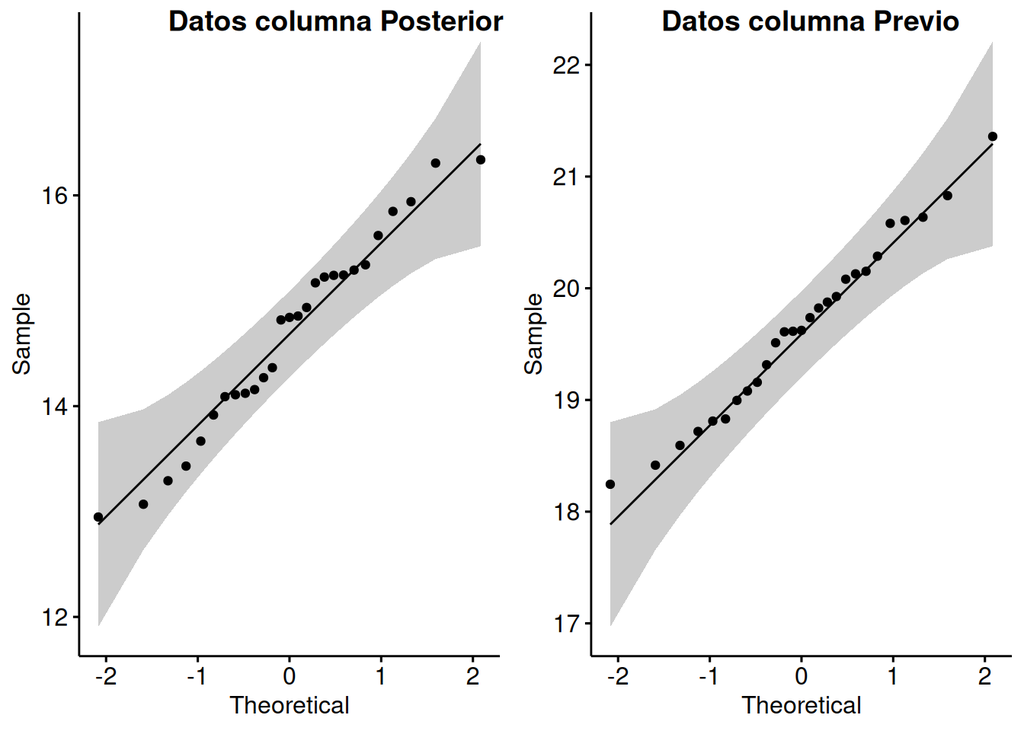

```r
g3<-ggqqplot(zonaCentroSur, x="Posterior")
g4<-ggqqplot(zonaCentroSur, x="Previo")

plot_grid(g3, g4, labels = c("Datos columna Posterior", "Datos columna Previo"))
```

Como se puede ver ambos p-values son mayores a 0.05 por lo que con un 95% de confianza no hay evidencia suficiente para rechzar que no haya normalidad y por el enunciado se puede deducir que las pruebas con independientes e independientes entre si

Ahora se definen las hipotesis:

- $H_O$: La diferencia de los promedio de los atletas del centro Norte es mayor por 3 segundos que los del centro Sur
- $H_A$ : Los promedios de los atletas de la zona entro norte es menos de 3 segundos que el promedio de los centro Sur

Donde matematicamente se veria así:

- $H_O$: $\mu_{CN} - \mu_{CS} \geq 3$
- $H_A$: $\mu_{CN}-\mu_{CS} < 3$

```r
prueba <- t.test(zonaCentroNorte$Previo , zonaCentroSur$Previo, paired = FALSE, alternative = "less", mu = 3, conf.level = 0.95)
prueba
```

```
##
##  Welch Two Sample t-test
##
## data:  zonaCentroNorte$Previo and zonaCentroSur$Previo
## t = -26.98, df = 50.026, p-value < 2.2e-16
## alternative hypothesis: true difference in means is less than 3
## 95 percent confidence interval:
##       -Inf -2.811139
## sample estimates:
## mean of x mean of y
##  16.45381  19.64981
```

```r
diferencia <- prueba[["estimate"]][1] - prueba[["estimate"]][2]
diferencia
```

```
## mean of x
## -3.196007
```

## Pregunta 4

¿Será cierto que hay más atletas de la zona Centro-Sur que redujeron sus mejores marcas en al menos 4,3 segundos que atletas de la zona Sur que lo hicieron en al menos 1,4 segundos?

Para poder responde a la pregunta, separamos los datos necesarios:

```r
## Se obtiene la mejopra de los atletas
datos$Mejora <- datos$Previo - datos$Posterior

## Se separan por zona
zonaCentroSur <- datos[datos$Zona == "Centro-Sur",]
zonaSur <- datos[datos$Zona == "Sur",]
```

Ahora comprobamos si se cumple las condiciones para realizar el método de Wald para dos muestras

```r
## Analizamos normalidad para las muestras
shapiro.test(zonaCentroSur$Mejora) ## p = 0.6839
```

```
##
##  Shapiro-Wilk normality test
##
## data:  zonaCentroSur$Mejora
## W = 0.97305, p-value = 0.6839
```

```r
shapiro.test(zonaSur$Mejora) ## p = 0.8027
```

```
##
##  Shapiro-Wilk normality test
##
## data:  zonaSur$Mejora
## W = 0.9781, p-value = 0.8027
```

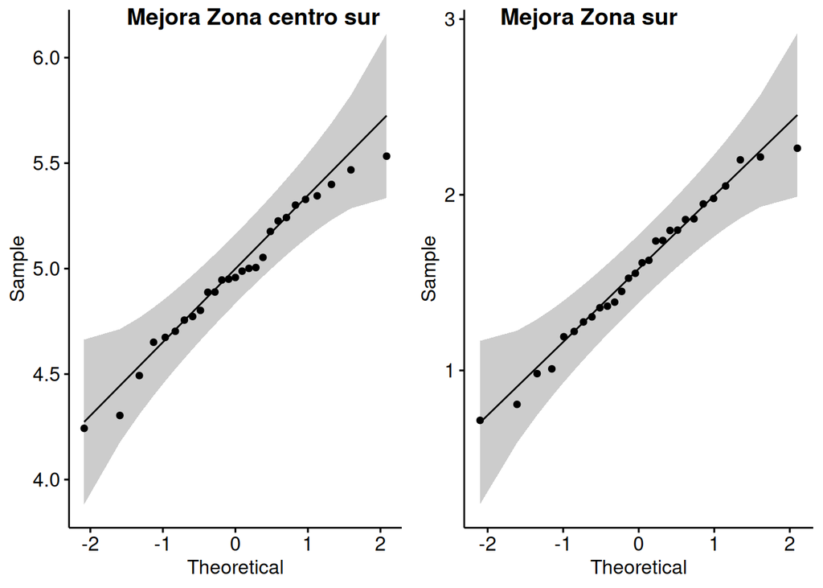

```r
g5<-ggqqplot(zonaCentroSur, x="Mejora")
g6<-ggqqplot(zonaSur, x="Mejora")

plot_grid(g5, g6, labels = c("Mejora Zona centro sur", "Mejora Zona sur"))
```

Como el calor p es alto, no hay evidencia suficiente para rechazar la normalidad de las muestras por lo que se trabajaran como muestras de distribuición normal. Ademas por el enunciado sabemos que los datos de las muestras son independientes una de la otra

A continuación se definen las hipotesis:

- $H_O$: Proporcion de los atletas del Centro Sur es menor que la proporcioón de los atletas del Sur
- $H_A$: Proporcion de los atletas del Centro Sur es mayor que la proporcion de los atletas del Sur

Matematicamente:

- $H_O$: $p_{CS} \le p_S$
- $H_A$: $p_{CS} > p_S$

```r
## Se cuenta cuantos datos por muestra son los que afectan nuestra prporcion
mayorCuatroTres <- sum(zonaCentroSur$Mejora >= 4.3)
mayorUnoCuatro <- sum(zonaSur$Mejora >= 1.4)

## Se cuentas la cantidad de las muestras
summary(zonaCentroSur)  ## n = 27
```

```
##        Id            Zona               Previo        Posterior
##  Min.   : 1.00   Length:27          Min.   :18.25   Min.   :12.95
##  1st Qu.:33.00   Class :character   1st Qu.:19.04   1st Qu.:14.10
##  Median :48.00   Mode  :character   Median :19.62   Median :14.84
##  Mean   :44.48                      Mean   :19.65   Mean   :14.68
##  3rd Qu.:64.00                      3rd Qu.:20.14   3rd Qu.:15.27
##  Max.   :80.00                      Max.   :21.36   Max.   :16.34
##      Mejora
##  Min.   :4.243
##  1st Qu.:4.764
##  Median :4.958
##  Mean   :4.966
##  3rd Qu.:5.234
##  Max.   :5.533
```

```r
summary(zonaSur)        ## n = 28
```

```
##        Id            Zona               Previo        Posterior
##  Min.   : 5.00   Length:28          Min.   :11.96   Min.   :10.69
##  1st Qu.:17.75   Class :character   1st Qu.:13.23   1st Qu.:11.82
##  Median :34.00   Mode  :character   Median :14.03   Median :12.42
##  Mean   :37.71                      Mean   :14.11   Mean   :12.55
##  3rd Qu.:58.25                      3rd Qu.:14.84   3rd Qu.:13.09
##  Max.   :81.00                      Max.   :17.30   Max.   :15.99
##      Mejora
##  Min.   :0.716
##  1st Qu.:1.298
##  Median :1.583
##  Mean   :1.566
##  3rd Qu.:1.860
##  Max.   :2.265
```

A continuacion con los datos obtenidos realizamos la prueba de proporción

```r
prueba <- prop.test(c(mayorCuatroTres, mayorUnoCuatro), c(27,28), alternative = "greater", conf.level = 0.95)
prueba
```

```
##
##  2-sample test for equality of proportions with continuity correction
##
## data:  c(mayorCuatroTres, mayorUnoCuatro) out of c(27, 28)
## X-squared = 8.2229, df = 1, p-value = 0.002068
## alternative hypothesis: greater
## 95 percent confidence interval:
##  0.1562842 1.0000000
## sample estimates:
##    prop 1    prop 2
## 0.9629630 0.6071429
```

Como se observa en el codigo anterior el valor p es 0.0020 lo cual es mnor a 0.05, por lo que se rechaza la hipotesis nula en favor de la hipotesis altenativa lo que quiere decir que la proporcion de los atletas de la zona centro sur que mejoraron su tiempo en 4.3 segundos es mayor en comparacion de los atletas del Sur que mejoraron 1.4 segundos.